# Hate Speech Detection - Facebook AI data

Vinita Vader

```r
# Seed for random number generation
set.seed(42)
knitr::opts_chunk$set(cache.extra = knitr::rand_seed,
                      message = FALSE,
                      warning = FALSE)
```

# Research problem

The lines between freedom of speech and offensive speech are filled with confusion in the age of freedom of choice and information dissemination on social media platforms. Honesty in thought could be a potential violation of someone’s right to function in a respectable manner in a society. The constant suspension of morality in the milieu of right to perspectives has been detrimental to attaining a universal grammar for understanding the meaning of rights and violation of rights. Although the philosophical debate around this issue could surface several deep seated issues about morality of offense and integrity, it is important to consider that discomfort caused to anyone is crucial to any form of action - online or offline - to be considered as harmful for the society. A recent study by [@williams2020hate] demonstrated how hate speech could influence political votes, terror attacks and promote criminal behavior by normalizing violence.

Bias in model performance, assessed based on sensitivity and accuracy analyses, will provide implications about groupings in the real world. Given that these algorithms might be used in legal and political settings (eg., what is the probability that a certain tweet invoked violence against group X), it important to assess their performance in generating appropriate inferences. A biased algorithm may lead to injustice towards certain groups in the society. The models resulting through the analysis in this report could be used as a starting point for evaluating bias in algorithms classifying hate speech. The results could also provide guidelines for caution while trusting outcomes based on RoBERTa models.

```r
#import
set.seed(123)
data_all<- rio::import(here::here("data", "data_all.csv"), setclass = "tbl_df")
data_unclean<- rio::import(here::here("data", "data_all.csv"), setclass = "tbl_df") %>%   characterize() %>%
  janitor::clean_names() %>%
  sample_n(1000) %>%
  data.frame()

#data for this study - 1000 random samples from the dataset will be analyzed for this study
#rio::export(data_unclean, file = "data.csv")

#final data to be used for the study
data_unclean <- rio::import(here::here("data", "data.csv"), setclass = "tbl_df")
```

```r
#functions
#vip plot
hyperP_fig <- function(df){
  ggplot(
    df, aes(x = lambda, y =logLoss)
  ) +
  geom_point(alpha = .5, color = "cornflowerblue") +
  labs(
    x = "Regularization parameter",
    y = "LogLoss(Cross-Validation)"
  ) +
  theme_minimal()
}

#estimates of vip
tidy_coef <- function(x){

  x %>%
   matrix %>%
   as_tibble %>%
   rownames_to_column %>%
     mutate(feature = sub("^", "Dim", rowname)) %>%
     select(-rowname, feature,  "estimate" = V1 ) %>%
      arrange(desc(estimate)) %>%
       head(10)

}
```

# Description of the data

```r
#figures and text required for the text below
colnames <- names(data_unclean)
data <- data_unclean %>%
  select("text", "label")

label_count <- data %>%
 rename("Label" = "label") %>%
 count(Label)
```

## Data generation process

The dataset has been built synthetically as a result of an AI improvement initiative by the Facebook AI division.The process of generating this data has been described below: Writers recruited for the task were provided with a certain context and target for whom they created some speech text categorized as hate or no hate (H and NH) speech. The target of the specch and the sentiment - H or NH - were set *a* *priori* to the generation of speech text by each writer. These texts were inputs for models (generated by Facebook) to test algorithms which best categorized the text the speeches as H or NH. If the model classified the text correctly, the speech text is retained as a good training example. If the model failed to classify the text correctly a verifier (person) was called in. The verifier - if he disagreed with the writer, the speech was trashed but if he agreed with the writer the speech text was retained for testing or developing the model.

## Data features

The original data consists of 40623 synthetically produced speech texts.For the current project we will be using 1000 randomly sampled speech texts. The original data file consists of the following columns - v1, id, text, label, type, model_wrong, db_model_preds, status, round, split, annotator.

For the purpose of the current study we are only interested in two columns, namely - text, label. The text variable consists of all the synthetically generated speech texts. The label variable consists of the type of text speech produced.

```r
ff_glimpse(data)$Categorical %>%
  kbl() %>%
    kable_paper() %>%
  kable_styling(latex_options = "hold_position") %>%
  scroll_box(width = "100%", height = "200px")
```

var_type

n

missing_n

missing_percent

levels_n

levels

levels_count

levels_percent

text

text

<chr>

1000

0

0.0

1000

label

label

<chr>

1000

0

0.0

2

```r
label_count %>%
 kbl() %>%
    kable_paper() %>%
  kable_styling(latex_options = "hold_position")
```

| Label | n |
| --- | --- |
| hate | 562 |
| nothate | 438 |

# Description of the models

> List at least three different modeling approaches you apply to this dataset. Describe each model, why the given model was selected, which hyperparameters to be optimized and how. Also, discuss how you plan to evaluate model performance.

The research problem in this study can be best defined as a classification problem. For testing the classification of text as H and NH speech, generalized linear models will be applied. The data will be modeled using Logistic regression without regularization and with regularization (ridge and lasso). Logistic regression is a powerful supervised machine learning classification model used for classification problems. It is very easy to realize and achieves good performance with linearly separable classes. It is extensively employed across several classification problems in various disciplines. We will start with the simplest model before moving forward with more complex models.

For optimizing the Logistic regression model we will also use L1 and L2 regularization. The $\lambda$ hyperparameter will be tuned for *Ridge regression* and *Lasso regression*. The $\alpha$ hyperparameter will be set to 0 for Ridge regularization and 1 for Lasso regularization.

The performance evaluation metrics on the test data would include computing *LogLikelihood (LL), Area under the curve (AUC), Accuracy (ACC), True Positive rate (TPR), True Negative rate (TNR), False Positive rate (FPR), and Precision (PRE)*.

### Analysis steps:

1. Create word embeddings - (Roberta based - layer 12 will be utilized for this step)
2. Logistic regression - cross validation with 80% training data
3. Logistic regression Lasso - cross validation with 80% training data
4. Logistic regression Ridge - cross validation with 80% training data
5. Evaluation metrics - compute across models and make model performance comparisons

```r
#Layer 12
word_embeds <- vector('list',nrow(data))

 for(i in 1:nrow(data)){
   # Assign the text to analyze
      text <- data[i,]$text

    word_embeds[i]  <- textEmbed(x = text,
                      model = 'roberta-base',
                      layers = 12)

 }
```

```r
# Creating dataframe
data <- data %>%
  mutate(id_col = 1:nrow(data))

#View(iter)
iter_12 <- data.frame(matrix(unlist(word_embeds), nrow=length(word_embeds), byrow=TRUE))

#Get dim names
# Creating vector of dim names
y <- textEmbed(x = data$text[1],
            model = 'roberta-base',
                  layers = 12)
y <- y[["x"]]
y <- names(y)

#Change column names of iter
colnames(iter_12) <-  y

iter_12 <- iter_12 %>%
  mutate(id_col = 1:nrow(data))

data_merge <- inner_join(data, iter_12, by = "id_col")
#names(data_merge)

# Removing unnecessary columns
data_12 <- data_merge %>%
  select(-c(text, id_col)) %>%
  rename("Label" = "label")

#str(data_12)
```

```r
outcome <- c('Label')
numeric <- y

blueprint_12 <- recipe(
  x = data_12,
  vars = colnames(data_12),
  roles =  c('outcome', rep('predictor', 768))) %>%
    step_normalize(all_of(numeric))
blueprint_12

prepare_12 <- prep(blueprint_12, training = data_12)
prepare_12

baked_data_12 <- bake(prepare_12, new_data = data_12)
baked_data_12

#rio::export(baked_data_12, file = "baked_data_12.csv")
```

```r
baked_data_12 <- rio::import(here::here("data", "baked_data_12.csv"), setclass = "tbl_df")
```

```r
set.seed(10152)  # for reproducibility
#80% training and 20% testing data
data_12_tr <- baked_data_12 %>%
  sample_frac(.8)
data_12_te <- anti_join(baked_data_12, data_12_tr)
```

## Logistic regression

```r
load("~/Desktop/Hate Speech Project/Until_LogReg.RData")
```

```r
#Logistic regression data_12
options(digits=2)
set.seed(10152021)  # for reproducibility

# Randomly shuffle the data
data_12_tr= data_12_tr[sample(nrow(data_12_tr)),]

# Create 10 folds with equal size
folds = cut(seq(1,nrow(data_12_tr)),breaks=10,labels=FALSE)

   # Create the list for each fold
      my.indices <- vector('list',10)
      for(i in 1:10){
        my.indices[[i]] <- which(folds!=i)
      }

cv <- trainControl(method = "cv",
                   index  = my.indices,
                   classProbs = TRUE,
                   summaryFunction = mnLogLoss)
```

```r
# Train the model
caret_mod_12 <- caret::train(blueprint_12,
                          data      = data_12_tr,
                          method    = "glm",
                          family = "binomial",
                          trControl = cv)
caret_mod_12
```

```r
# Predict the probabilities for the observations in the test dataset
predicted_te_12 <- predict(caret_mod_12, data_12_te, type='prob')
#predicted_te_12


#------Evaluation of model------#
# Compute the AUC
cut.obj_12 <- cutpointr(x     = predicted_te_12$hate,
                       class = data_12_te$Label)
auc_LR_12 <-  auc(cut.obj_12)


# Confusion matrix assuming the threshold is 0.5
pred_class_12 <- ifelse(predicted_te_12$hate>.5,1,0)

confusion_12 <- table(data_12_te$Label,pred_class_12)
confusion_12
```

```
##          pred_class_12
##            0  1
##   hate    49 65
##   nothate 42 44
```

```r
# True Negative Rate
TNR_LR_12 <- confusion_12[1,1]/(confusion_12[1,1]+confusion_12[1,2])

# False Positive Rate
FPR_LR_12 <- confusion_12[1,2]/(confusion_12[1,1]+confusion_12[1,2])

# True Positive Rate
TPR_LR_12 <- confusion_12[2,2]/(confusion_12[2,1]+confusion_12[2,2])

# Precision
PRE_LR_12 <- confusion_12[2,2]/(confusion_12[1,2]+confusion_12[2,2])

#Accuracy
ACC_LR_12 <- (confusion_12[1,1]+confusion_12[2,2])/(confusion_12[1,2] + confusion_12[2,1] + confusion_12[1,1] + confusion_12[2,2])
```

## Ridge regression

```r
# Cross-validation settings

cv <- trainControl(method    = "cv",
                   index           = my.indices,
                   classProbs      = TRUE,
                   summaryFunction = mnLogLoss)

# Hyperparameter tuning grid for ridge penalty (lambda), alpha = 0
grid <- data.frame(alpha = 0, lambda = c(seq(0.68,1.5, .01)))
```

```r
# Train the model
caret_logistic_ridge_12 <- caret::train(blueprint_12,
                                     data      = data_12_tr,
                                     method    = "glmnet",
                                     family    = 'binomial',
                                     metric    = 'logLoss',
                                     trControl = cv,
                                     tuneGrid  = grid)
caret_logistic_ridge_12
```

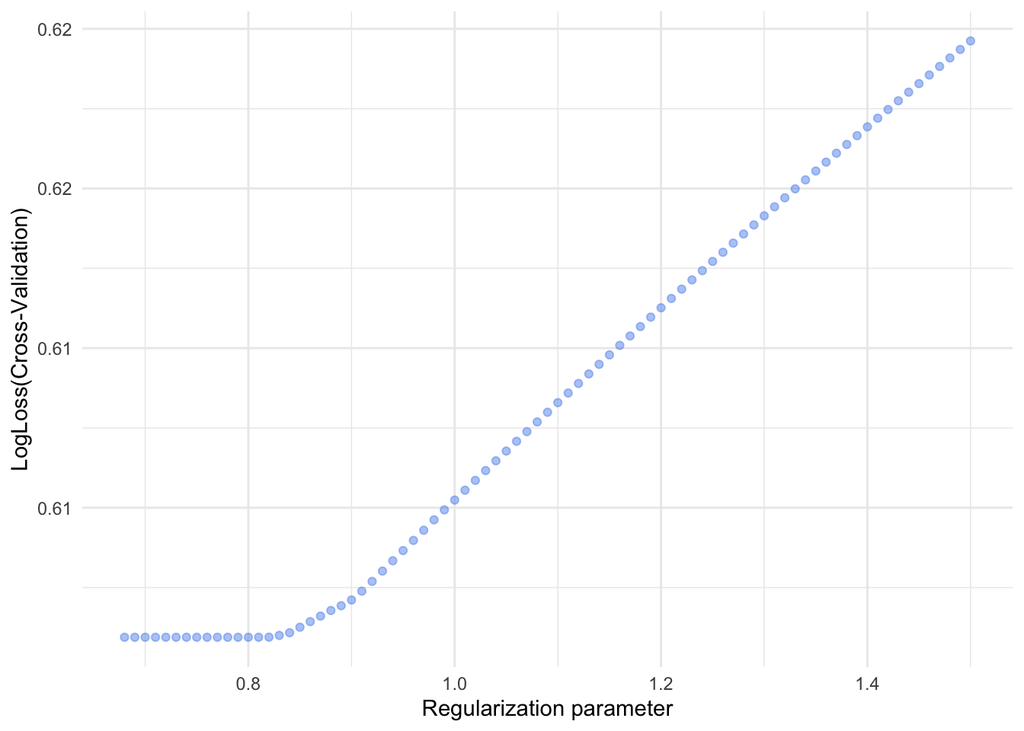

```r
# check the results
hyperP_fig(caret_logistic_ridge_12$results)
```

As seen in the above figure, hyperparameter $\lambda$ was set to be 0, 0.81

```r
# Predict the probabilities for the observations in the test dataset

predicted_te_12 <- predict(caret_logistic_ridge_12, data_12_te, type = 'prob')

# Compute the AUC
cut.obj <- cutpointr(x     = predicted_te_12$hate,
                     class = data_12_te$Label)
auc_LRr_12 <- auc(cut.obj)

# Confusion matrix assuming the threshold is 0.5
pred_class_12 <- ifelse(predicted_te_12$hate>.5,1,0)

confusion_ridge <- table(data_12_te$Label,pred_class_12)
#confusion_ridge

# True Negative Rate
TNR_LRr_12 <- confusion_ridge[1,1]/(confusion_ridge[1,1]+confusion_ridge[1,2])

# False Positive Rate
FPR_LRr_12 <- confusion_ridge[1,2]/(confusion_ridge[1,1]+confusion_ridge[1,2])

# True Positive Rate
TPR_LRr_12 <- confusion_ridge[2,2]/(confusion_ridge[2,1]+confusion_ridge[2,2])

# Precision
PRE_LRr_12 <- confusion_ridge[2,2]/(confusion_ridge[1,2]+confusion_ridge[2,2])

#Accuracy
ACC_LRr_12 <- (confusion_ridge[1,1]+confusion_ridge[2,2])/(confusion_ridge[1,2] + confusion_ridge[2,1] + confusion_ridge[1,1] + confusion_ridge[2,2])
```

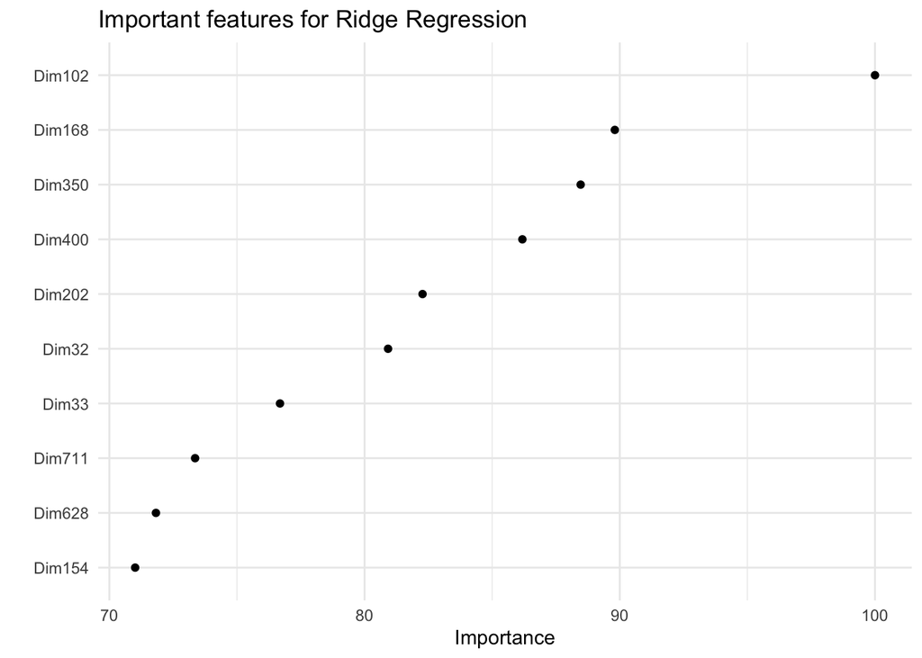

```r
vip(caret_logistic_ridge_12,
    num_features = 10,
    geom = "point") +
  labs(title = "Important features for Ridge Regression")+
  theme_minimal()
```

```r
coefs <- coef(caret_logistic_ridge_12$finalModel,caret_logistic_ridge_12$bestTune$lambda)
#length(coefs)

tidy_coef(coefs) %>%
  kable('html',align = 'c') %>%
    kable_paper() %>%
  kable_styling(position = "center", full_width = F) %>%
  scroll_box( height = "200px")
```

| estimate | feature |
| --- | --- |
| 0.04 | Dim169 |
| 0.04 | Dim351 |
| 0.04 | Dim203 |
| 0.03 | Dim712 |
| 0.03 | Dim629 |
| 0.03 | Dim155 |
| 0.03 | Dim157 |
| 0.03 | Dim768 |
| 0.03 | Dim215 |
| 0.03 | Dim664 |

```r
#head(as.matrix(coefs[ind,]),10)
```

## Lasso Regression

```r
# Cross-validation settings

cv <- trainControl(method    = "cv",
                   index           = my.indices,
                   classProbs      = TRUE,
                   summaryFunction = mnLogLoss)

# Hyperparameter tuning grid for ridge penalty (lambda), alpha = 0

grid <- data.frame(alpha = 1, lambda = seq(0.016,.018,.0001))
#grid
```

```r
# Train the model

caret_logistic_lasso_12 <- caret::train(blueprint_12,
                                     data      = data_12_tr,
                                     method    = "glmnet",
                                     family    = 'binomial',
                                     metric    = 'logLoss',
                                     trControl = cv,
                                     tuneGrid  = grid)

caret_logistic_lasso_12
```

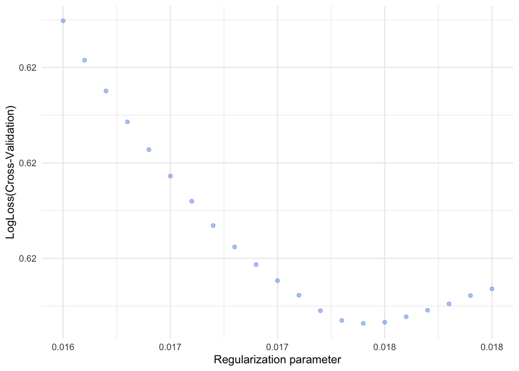

```r
# check the results
hyperP_fig(caret_logistic_lasso_12$results)
```

As seen in figure above the hyperparameter $\lambda$ was set to be 1, 0.02

```r
# Predict the probabilities for the observations in the test dataset

predicted_te_12 <- predict(caret_logistic_lasso_12, data_12_te, type='prob')

#dim(predicted_te_12)
#head(predicted_te_12)

# Compute the AUC
cut.obj <- cutpointr(x     = predicted_te_12$hate,
                     class = data_12_te$Label)
auc_LRl_12 <- auc(cut.obj)

# Confusion matrix assuming the threshold is 0.5
pred_class <- ifelse(data_12_te$hate>.5,1,0)
confusion_lasso <- table(data_12_te$Label,pred_class_12)
#confusion_lasso

# True Negative Rate
TNR_LRl_12 <- confusion_lasso[1,1]/(confusion_lasso[1,1]+confusion_lasso[1,2])

# False Positive Rate
FPR_LRl_12 <- confusion_lasso[1,2]/(confusion_lasso[1,1]+confusion_lasso[1,2])

# True Positive Rate
TPR_LRl_12 <- confusion_lasso[2,2]/(confusion_lasso[2,1]+confusion_lasso[2,2])

# Precision
PRE_LRl_12 <- confusion_lasso[2,2]/(confusion_lasso[1,2]+confusion_lasso[2,2])

#Accuracy
ACC_LRl_12 <- (confusion_lasso[1,1]+confusion_lasso[2,2])/(confusion_lasso[1,2] + confusion_lasso[2,1] + confusion_lasso[1,1]+ confusion_lasso[2,2])
```

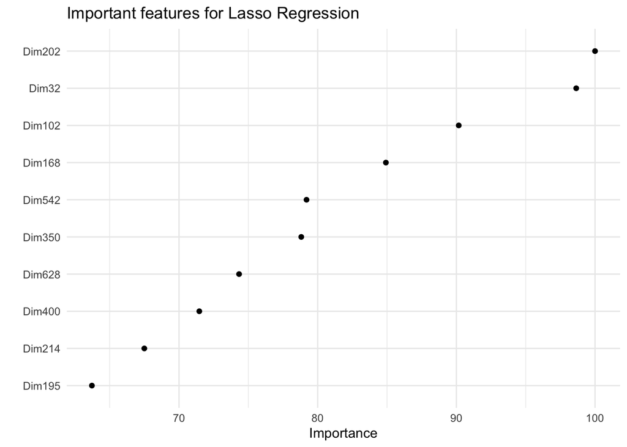

```r
vip(caret_logistic_lasso_12,
    num_features = 10,
    geom = "point") +
  labs(title = "Important features for Lasso Regression")+
  theme_minimal()
```

```r
coefs <- coef(caret_logistic_lasso_12$finalModel,
              caret_logistic_lasso_12$bestTune$lambda)

tidy_coef(coefs) %>%
 kable('html',align = 'c') %>%
    kable_paper() %>%
  kable_styling(position = "center", full_width = F) %>%
  scroll_box( height = "200px")
```

| estimate | feature |
| --- | --- |
| 0.22 | Dim203 |
| 0.19 | Dim169 |
| 0.17 | Dim543 |
| 0.17 | Dim351 |
| 0.16 | Dim629 |
| 0.15 | Dim215 |
| 0.14 | Dim196 |
| 0.11 | Dim717 |
| 0.11 | Dim155 |
| 0.11 | Dim768 |

```r
tibble(
      model = c("Logistic Regression",
            "Logistic Regression with Ridge Penalty",
            "Logistic Regression with Lasso Penalty"),

      "-LL" = c(caret_mod_12$results$logLoss,
              min(caret_logistic_ridge_12$results$logLoss),
              min(caret_logistic_lasso_12$results$logLoss)
              ),

      "AUC" = c(auc_LR_12, auc_LRr_12, auc_LRl_12),

      "ACC" = c(ACC_LR_12, ACC_LRr_12, ACC_LRl_12),

      "TPR" = c(TPR_LR_12, TPR_LRr_12, TPR_LRr_12),

      "TNR" = c(TNR_LR_12, TNR_LRr_12, TNR_LRl_12),

      "FPR" = c(FPR_LR_12, FPR_LRr_12, FPR_LRl_12),

      "PRE" = c(PRE_LR_12, PRE_LRr_12, PRE_LRl_12)

) %>%
  kbl() %>%
  kable_styling(position = "center") %>%
    kable_paper() %>%
  scroll_box(width = "100%", height = "150px")
```

| model | -LL | AUC | ACC | TPR | TNR | FPR | PRE |
| --- | --- | --- | --- | --- | --- | --- | --- |
| Logistic Regression | 16.19 | 0.54 | 0.47 | 0.51 | 0.43 | 0.57 | 0.40 |
| Logistic Regression with Ridge Penalty | 0.61 | 0.74 | 0.29 | 0.47 | 0.16 | 0.84 | 0.29 |
| Logistic Regression with Lasso Penalty | 0.62 | 0.71 | 0.29 | 0.47 | 0.16 | 0.84 | 0.29 |

# Discussion

Given the evaluation metrics for this data `Logistic Regression with Ridge regularization` would be the model I would choose for this data. Logistic regession model will not be the best model given the high Logloss value although it has a high precision rate compared to the other two models.

## Check for bias

Let us test the model on real some examples. I picked these examples at random from my Twitter feed.

```r
dat = tibble(
  text = c('Even without Omicron, the US would be facing difficult months ahead. Plain truth: It is likely going to be a hard winter, but we can reduce Covid transmission and save lives by increasing vaccinations, masking up, and balancing risks and benefits.',
           'Tomb of Qin Shi Huang is located in the north of Lishan Mountain in Lintong County, Xian City, Shaanxi Province, China.',
           'A rare seen picture of Bamiyan Buddha sculpture.',
           'I want go to school.',
           'China committed genocide against Uyghurs, independent tribunal rules',
            'Marriage is a union of men and women',
            'This stoneweight, made of haematite carved in the shape of a grasshopper, looks pretty modern',
            'Why when Jesus talks about feeding the poor, it’s christianity. But when a politician talks about feeding the poor, it’s socialism?',
           'Anne Hathaway and Jessica Chastain aka Chastway said GAY RIGHTS',
            'I’ve learned that you can tell a lot about a person by the way he handles these three things: a rainy day, lost luggage, and tangled Christmas tree lights',
            'Part of the perfection of ones Islam is his leaving that which does not concern him.',
            'Naturalism is far more probable than Islam',
            'Why do we have same-sex attraction in such high prevalence in human societies?',
            'If you believe in actual Christianity, you don’t support people who make a mockery of school shootings and continue promoting violence and bigotry',
            'We have had a president like Trump',
           'I am a convert to Islam. The things I have seen and heard regarding Muslim men taking advantage of vulnerable convert women are stomach-churning. There is usually a bit of a pattern, so I wanted to highlight some important points here.',
           'American rappers are now wearing make-up',
           'You can’t soak chocolate chips in rum',
           'Can taxpayers be forced to fund religious education?',
           ' In my experience, experiments are very effective at exploring a variety of ideas and surfacing the best ones.',
           'This is Waseem Rizvi who edited Quran in India & later accepted Hinduism',
           'Dolchstosslegende was a conspiracy theory promoted by the Nazis that it was the socialists, liberals and Jews that caused Germany to lose WW',
           'When we are interested in studying group differences, sometimes we may wish to annotate our visualizations with results from significance testing')
)
```

```r
#Layer 12
word_embeds_check <- vector('list',nrow(dat))

 for(i in 1:nrow(dat)){
   # Assign the text to analyze
      text <- dat[i,]$text

    word_embeds_check[i]  <- textEmbed(x = text,
                      model = 'roberta-base',
                      layers = 12)

 }
```

```r
# Creating dataframe
dat <- dat %>%
  mutate(id_col = 1:nrow(dat))

#View(iter)
iter_check_12 <- data.frame(matrix(unlist(word_embeds_check), nrow=length(word_embeds_check), byrow=TRUE))

#Get dim names
# Creating vector of dim names
y <- textEmbed(x = dat$text[1],
            model = 'roberta-base',
                  layers = 12)
y <- y[["x"]]
y <- names(y)

#Change column names of iter
colnames(iter_check_12) <-  y

iter_check_12  <- iter_check_12  %>%
  mutate(id_col = 1:nrow(dat))

data_merge <- inner_join(dat, iter_check_12 , by = "id_col")
#names(data_merge)

# Removing unnecessary columns
data_12 <- data_merge %>%
  select(- id_col) %>%
  data.frame()
#View(data_12)
```

```r
prob = predict(caret_logistic_ridge_12, data_12, type='prob')

#"Text" = (map(paste0("text", 1:9), get) %>% unlist),

tibble(
  "Text" = dat$text,

  "Hate speech" = prob$hate,

  "Not hate speech" = prob$nothate
)%>%
  kbl() %>%
   kable_styling() %>%
  kable_styling(latex_options = "hold_position") %>%
  kable_paper() %>%
  scroll_box(width = "100%", height = "300px")
```

| Text | Hate speech | Not hate speech |
| --- | --- | --- |
| Even without Omicron, the US would be facing difficult months ahead. Plain truth: It is likely going to be a hard winter, but we can reduce Covid transmission and save lives by increasing vaccinations… | 0.53 | 0.47 |
| Tomb of Qin Shi Huang is located in the north of Lishan Mountain in Lintong County, Xian City, Shaanxi Province, China. | 0.53 | 0.47 |
| A rare seen picture of Bamiyan Buddha sculpture. | 0.54 | 0.46 |
| I want go to school. | 0.53 | 0.47 |
| China committed genocide against Uyghurs, independent tribunal rules | 0.55 | 0.45 |
| Marriage is a union of men and women | 0.50 | 0.50 |
| This stoneweight, made of haematite carved in the shape of a grasshopper, looks pretty modern | 0.52 | 0.48 |
| Why when Jesus talks about feeding the poor, it’s christianity. But when a politician talks about feeding the poor, it’s socialism? | 0.53 | 0.47 |
| Anne Hathaway and Jessica Chastain aka Chastway said GAY RIGHTS | 0.53 | 0.47 |
| I’ve learned that you can tell a lot about a person by the way he handles these three things: a rainy day, lost luggage, and tangled Christmas tree lights | 0.51 | 0.49 |
| Part of the perfection of ones Islam is his leaving that which does not concern him. | 0.51 | 0.49 |
| Naturalism is far more probable than Islam | 0.53 | 0.47 |
| Why do we have same-sex attraction in such high prevalence in human societies? | 0.52 | 0.48 |
| If you believe in actual Christianity, you don’t support people who make a mockery of school shootings and continue promoting violence and bigotry | 0.52 | 0.48 |
| We have had a president like Trump | 0.54 | 0.46 |
| I am a convert to Islam. The things I have seen and heard regarding Muslim men taking advantage of vulnerable convert women are stomach-churning. There is usually a bit of a pattern, so I wanted to hi… | 0.52 | 0.48 |
| American rappers are now wearing make-up | 0.53 | 0.47 |
| You can’t soak chocolate chips in rum | 0.54 | 0.46 |
| Can taxpayers be forced to fund religious education? | 0.55 | 0.45 |
| In my experience, experiments are very effective at exploring a variety of ideas and surfacing the best ones. | 0.50 | 0.50 |
| This is Waseem Rizvi who edited Quran in India & later accepted Hinduism | 0.55 | 0.45 |
| Dolchstosslegende was a conspiracy theory promoted by the Nazis that it was the socialists, liberals and Jews that caused Germany to lose WW | 0.55 | 0.45 |
| When we are interested in studying group differences, sometimes we may wish to annotate our visualizations with results from significance testing | 0.52 | 0.48 |

The news about Omicron was not something I was expecting to have a high probability for Hate speech. There is a sentiment of threat in that statement but it does not qualify as hate speech. The information about the *Tomb of Qin Shi Huang* - {Tomb of Qin Shi Huang is located in the north of Lishan Mountain in Lintong County, Xian City, Shaanxi Province, China.} - was in fact of the most harmless tweets in this dataset, describing the location of historical monument. I wonder what is it about the willingness to go to school - {I want go to school.} - that can deem this as Hate speech. When celebrities support causes -{Anne Hathaway and Jessica Chastain aka Chastway said GAY RIGHTS} - you would ideally expect this to indicate positive speech. It is hard to determine if a text is hate speech if it is likely to speak for both sides of the argument - {Can taxpayers be forced to fund religious education?}; however when questions are posed in media, it is highly unlikely that they could potentially conduct hate speech through such article headlines or discussion prompts.

## Closer look at the data

```r
glimpse(data_all)
```

```
## Rows: 40,623
## Columns: 11
## $ V1             <int> 1, 2, 3, 4, 5, 6, 7, 8, 9, 10, 11, 12, 13, 14, 15, 16, …
## $ id             <chr> "10000", "10001", "10002", "10003", "10004", "10005", "…
## $ text           <chr> "It should be legal for a husband to rape his wife", "d…
## $ label          <chr> "hate", "hate", "hate", "hate", "hate", "hate", "hate",…
## $ type           <chr> "notgiven", "notgiven", "notgiven", "notgiven", "notgiv…
## $ model_wrong    <lgl> TRUE, FALSE, TRUE, TRUE, TRUE, TRUE, TRUE, TRUE, TRUE, …
## $ db.model_preds <dbl> 0.975, 0.082, 0.923, 0.990, 0.988, 0.995, 0.993, 0.986,…
## $ status         <chr> "dynabench entry", "dynabench entry", "dynabench entry"…
## $ round          <chr> "1", "1", "1", "1", "1", "1", "1", "1", "1", "1", "1", …
## $ split          <chr> "train", "test", "train", "test", "train", "train", "tr…
## $ annotator      <chr> "gnzuctwed3", "cagnluiznm", "cagnluiznm", "gnzuctwed3",…
```

To begin with the overall data set, it does not provide who the target of the text was. This leaves us with the option o determining who the potential target of the text must be given the text. Here we will first remove the *stopwords* and then count the occurrences of words in the text. *Stop words* are frequent words but provide little information. Some common English stop words include “I”, “she’ll”, “the”, etc. In the `{tm}` package, there are 174` stop words on this common list. Let’s look at this list of stop words.

```r
stopwords("en")
```

```
##   [1] "i"          "me"         "my"         "myself"     "we"
##   [6] "our"        "ours"       "ourselves"  "you"        "your"
##  [11] "yours"      "yourself"   "yourselves" "he"         "him"
##  [16] "his"        "himself"    "she"        "her"        "hers"
##  [21] "herself"    "it"         "its"        "itself"     "they"
##  [26] "them"       "their"      "theirs"     "themselves" "what"
##  [31] "which"      "who"        "whom"       "this"       "that"
##  [36] "these"      "those"      "am"         "is"         "are"
##  [41] "was"        "were"       "be"         "been"       "being"
##  [46] "have"       "has"        "had"        "having"     "do"
##  [51] "does"       "did"        "doing"      "would"      "should"
##  [56] "could"      "ought"      "i'm"        "you're"     "he's"
##  [61] "she's"      "it's"       "we're"      "they're"    "i've"
##  [66] "you've"     "we've"      "they've"    "i'd"        "you'd"
##  [71] "he'd"       "she'd"      "we'd"       "they'd"     "i'll"
```

[output cut: 20 more lines]

```r
#Functions for carrying out the tasks below
#Can set include = F when knitting this for the final website.

plot_frequent <- function(group_membership){

    df = data_all%>%
  select(text ) %>%
  mutate(text = tolower(text)) %>%
  filter(str_detect(text, {{group_membership}})) %>%
  str_c(.)

    frequent_terms <- freq_terms(removeWords(df, stopwords("en")), 30)

  plot = frequent_terms %>%
    ggplot( aes(x = reorder(WORD, FREQ), y = FREQ))+
          geom_col(stat = "identity", fill = "cornflowerblue", alpha = .65)+
        labs(title = {{group_membership}},
             x = "WORD",
             y = "FREQ") +
        guides(fill = "none")+
    theme_minimal()+
    coord_flip()

  return(plot)
}


plot_hate <- function(group_membership){
 df = data_all%>%
  filter(label == "hate") %>%
  select(text ) %>%
  mutate(text = tolower(text)) %>%
  filter(str_detect(text, {{group_membership}})) %>%
  str_c(.)

    frequent_terms <- freq_terms(removeWords(df, stopwords("en")))

  plot = frequent_terms %>%
    ggplot( aes(x = reorder(WORD, FREQ), y = FREQ))+
          geom_col(stat = "identity", fill = "cornflowerblue", alpha = .65)+
        labs(title = paste({{group_membership}},"-","hate speech"),
             x = "WORD",
             y = "FREQ") +
        guides(fill = "none")+
    theme_minimal()+
    coord_flip()

   return(plot)

  }

n_times <- function(religion){
  data_all %>%
  filter(str_detect(text, {{religion}})) %>%
  nrow()
}
```

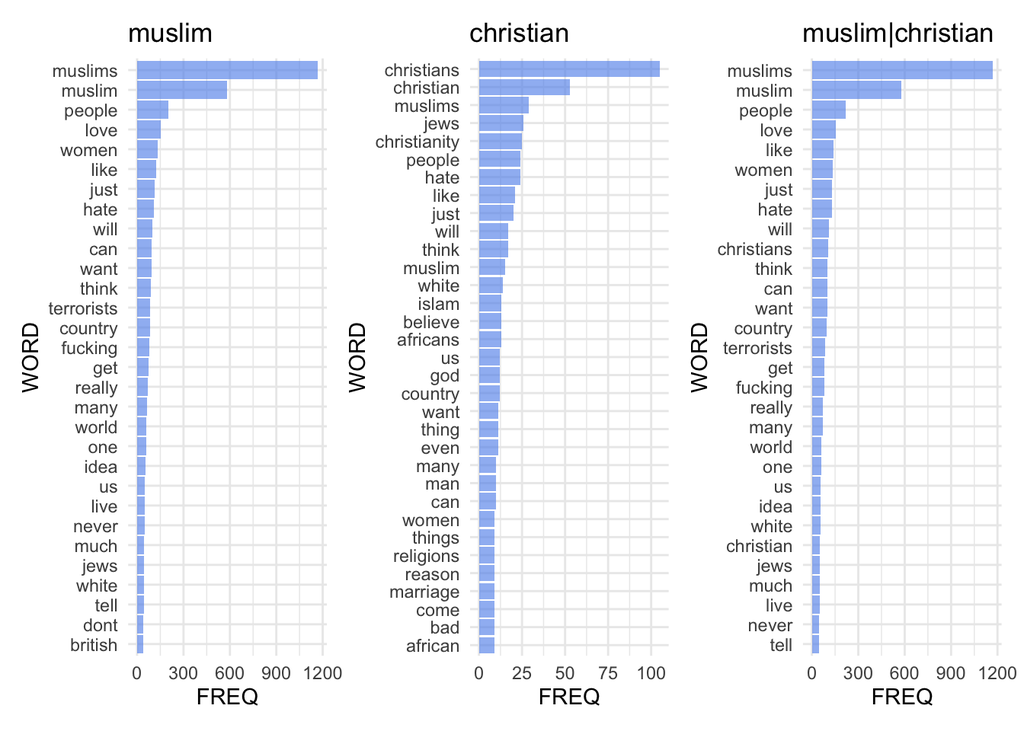

```r
#Let's look at texts which contain Muslims, Christians and both
religion_mc <- c("muslim", "christian", "muslim|christian")
plots_mc = map(religion_mc, plot_frequent)
plots_mc[[1]]+plots_mc[[2]]+plots_mc[[3]]
```

These plots only display the highest frequency words and drop those with lower frequency. There is a chance that given the target is *Christians* writers are likely to mention *Muslims* and even *Jews* very frequently, but this cannot be said for -Muslims_. The word “terrorists” is likely to be used for Muslims but not for Christians. It is interesting how the word “women” comes up in the Muslim plot and both “man” and “women” comes up in high frequency the Christian plot. The word “marriage” and “god” is also highly frequent in texts consisting the word Christian targets.

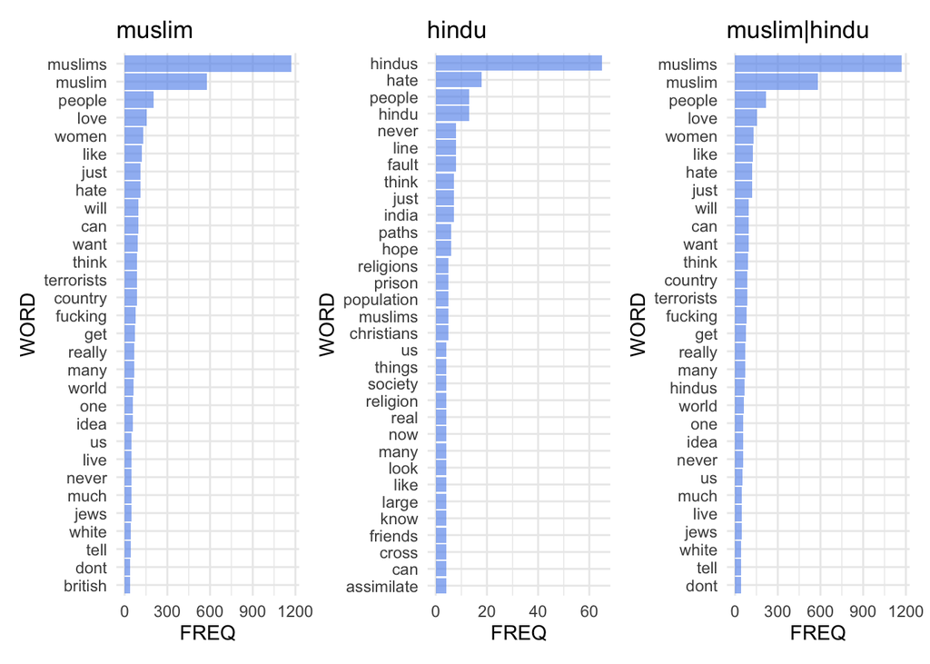

```r
#Let's look at texts which contain Muslims, Christians and both
religion_mh <- c("muslim", "hindu", "muslim|hindu")
plots_mh = map(religion_mh, plot_frequent)
plots_mh[[1]]+plots_mh[[2]]+plots_mh[[3]]
```

Interestingly, the word “India” comes up in the frequency plot for text consisting of word “Hindu”. The “Muslim” and “Christian” also make a frequency appearance in these texts. This brief look at the data indicates potential biases while building texts for these targets. More than building training sets on texts which are a result of people unknowingly generating hate or no hate speech the Facebook AI model draws inferences based on training data which is *supposed* to be hate or no hate speech as the writers were commanded to do so. One could make an argument that the development of these texts is equivalent to the process of obtaining a high score on the personality dimension of Extraversion because one was told to be high on Extraversion. It also means that this data can go into developing training data for a model which predicts mental health outcomes based on Extraversion. There are strong reasons to keep the purpose of the study away from the participants in Psychology research as it implies more honesty and true projection of their latent variables on the survey responses.

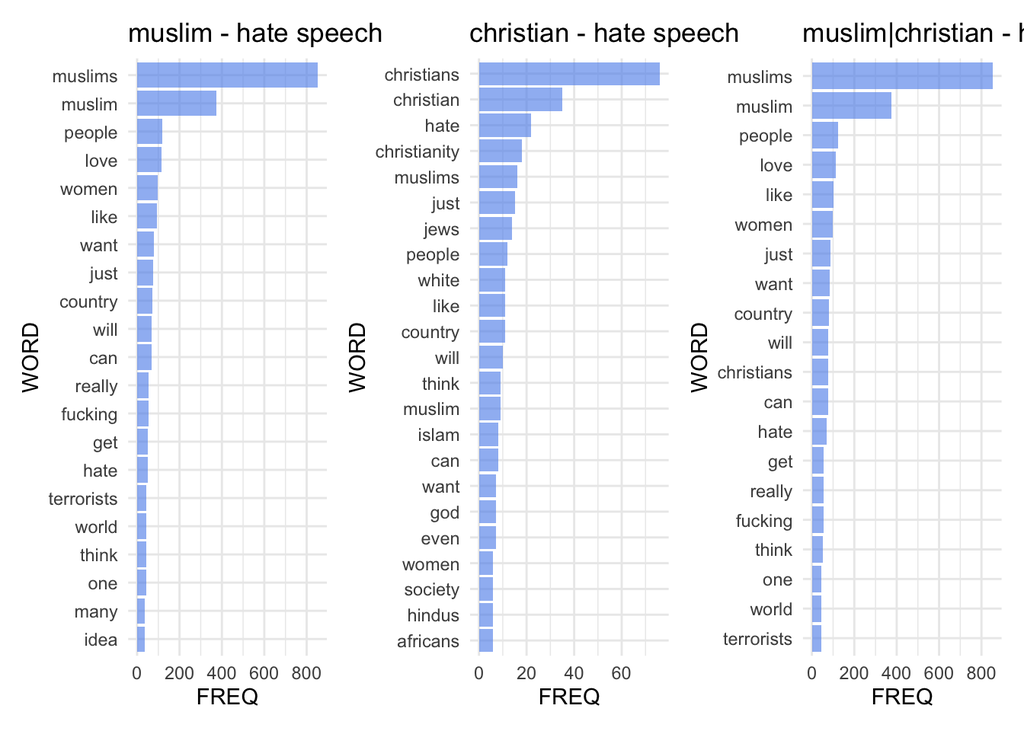

```r
religion_mc <- c("muslim", "christian", "muslim|christian")
plots_mc_hate = map(religion_mc, plot_hate)
plots_mc_hate[[1]]+plots_mc_hate[[2]]+plots_mc_hate[[3]]
```

Let’s look at this one last plot which specifically looks at hate speech text. Once again, texts which consist of the word “Christian” in them are likely to consist of other religions such as “Jews”, “Muslim and”Islam", indicating some bias in the way these texts have been generated by the writers. One way of dealing with such issues could be diversifying the writers both socially and geographically. In conclusion, although this an important step towards generating more robust models in detecting hate speech, it has its drawbacks.